# Assignment 4: Movie Review Analysis [50 Pt]

## Part 4. Evaluation [10 pt]

**Important**. At this point in the assignment your test data should not have been evaluated by any of your models. The test data should be evaluated only after you have finished all the previous parts of the assignment. Once you evaluate your models on the test data you cannot change your models or else you may make hyperparameter adjustments that could lead to overfitting to the test data.

### Part (i) [3pt RESULT]

Report the final test accuracy of your model. Comment on how the result compares with accuracy obtained on the training and validation data. Are the results what you expected? Explain.

```python
# TO BE COMPLETED

test_loader = torch.utils.data.DataLoader(test, batch_size=16)

test_acc = get_accuracy(model_2, test_loader)

print(f"The test accuracy is {test_acc*100} %")
```

```
The test accuracy is 84.66 %
```

```python
'''
PROVIDE YOUR ANSWER BELOW
---------------------------------------------------------------------------

The final test accuracy of the model_2, evaluated on the test data, is 84.66%.


Training Accuracy: At the end of training (epoch 10), the model achieved a
training accuracy of approximately 88.8%.

Validation Accuracy: The validation accuracy at epoch 10 was around 85%.

The test accuracy is quite close to the validation accuracy, indicating that
the model generalizes well to unseen data. This alignment between the
validation and test accuracies suggests that the model did not overfit to
the training data, which is a positive sign.

While the test accuracy is slightly lower than the training accuracy,
this is expected as the model is evaluated on unseen data during testing,
which may contain additional variability compared to the training data.

Overall, the results align well with expectations, indicating that
the model has learned meaningful patterns from the data and performs
reasonably well on unseen data.



'''
```

### Part (ii) [3pt DISCUSSION]

Look over the misclassified samples in the test data and see if you can find any patterns on where the model has difficulty with identifying the review sentiment. Provide up to 5 examples of positive and negative reviews each to support your findings.

```python
# Evaluate model on test data
misclassified_positive_samples = []
misclassified_negative_samples = []

_,_,x_org = split_data(X,y)

i = 0
for reviews, labels in test_loader:
    output = model_2(reviews)
    pred = output.max(1, keepdim=True)[1]
    tensorr=pred.eq(labels.view_as(pred))
    ind=torch.where(tensorr == False)[0]
    for ele in ind.tolist():
        if labels[ele] == 1:  # Positive review misclassified as negative
            misclassified_positive_samples.append((x_org[ele+i], labels[ele], pred[ele]))
            if len(misclassified_positive_samples) == 5:
                break
        else:  # Negative review misclassified as positive
            misclassified_negative_samples.append((x_org[ele+i], labels[ele], pred[ele]))
            if len(misclassified_negative_samples) == 5:
                break
    if len(misclassified_positive_samples) == 5 and len(misclassified_negative_samples) == 5:
        break

# Print misclassified positive reviews
print("Misclassified Positive Reviews:")
for review, true_label, prediction in misclassified_positive_samples:
    print("Review:", review)
    print("True label:", true_label)
    print("Prediction:", prediction)

# Print misclassified negative reviews
print("\nMisclassified Negative Reviews:")
for review, true_label, prediction in misclassified_negative_samples:
    print("Review:", review)
    print("True label:", true_label)
    print("Prediction:", prediction)
```

```
Misclassified Positive Reviews:
Review: ('First of all, let\'s get a few things straight here: a) I AM an anime fan- always has been as a matter of fact (I used to watch Speed Racer all the time in Preschool). b) I DO like several B-Movies because they\'re hilarious. c) I like the Godzilla movies- a lot.<br /><br />Moving on, when…
True label: tensor(1)
Prediction: tensor([0])
Review: ("I am not a golf fan by any means. On May 26 about 10:30 PM the movie started with a scene in the late 1800's. Old movies I like but not golf however, within the first scene a young boy (Harry Vardon) is awaken by the voices of men. He goes outside to inquire what they are doing and is told…
True label: tensor(1)
Prediction: tensor([0])
Review: ('This movie was so frustrating. Everything seemed energetic and I was totally prepared to have a good time. I at least thought I\'d be able to stand it. But, I was wrong. First, the weird looping? It was like watching "America\'s Funniest Home Videos". The damn parents. I hated them so much…
True label: tensor(1)
Prediction: tensor([0])
Review: ('I cannot believe I enjoyed this as much as I did. The anthology stories were better than par, but the linking story and its surprise ending hooked me. Alot of familiar faces will keep you asking yourself "where I have I seen them before?" Forget the running time listed on New Line\'s tape,…
True label: tensor(1)
Prediction: tensor([0])
Review: ("NO SPOILERS!!<br /><br />After Hitchcock's successful first American film, Rebecca based upon Daphne DuMarier's lush novel of gothic romance and intrigue, he returned to some of the more familiar themes of his early British period - mistaken identity and espionage. As the U.S. settled into…
True label: tensor(1)
Prediction: tensor([0])

Misclassified Negative Reviews:
Review: ('I\'m not sure why the producers needed to trade on the name of a somewhat successful movie franchise because the title suggests that it is a sequel to the first three movies..which it is not. Even though Marques Houston did appear in "HP3", he played a totally different character (he was, …
True label: tensor(0)
Prediction: tensor([1])
Review: ("The few scenes that actually attempt a depiction of revolutionary struggle resemble a hirsute Boy Scout troop meandering tentatively between swimming holes. When Sharif or, please God, Palance try their hand at fiery oratory, they sound like Kurtz swallowing a bug. The displays of strategi…
True label: tensor(0)
Prediction: tensor([1])
Review: ("The cast played Shakespeare.<br /><br />Shakespeare lost.<br /><br />I appreciate that this is trying to bring Shakespeare to the masses, but why ruin something so good.<br /><br />Is it because 'The Scottish Play' is my favorite Shakespeare? I do not know. What I do know is that a certain…
True label: tensor(0)
Prediction: tensor([1])
Review: ('I\'m not sure why the producers needed to trade on the name of a somewhat successful movie franchise because the title suggests that it is a sequel to the first three movies..which it is not. Even though Marques Houston did appear in "HP3", he played a totally different character (he was, …
True label: tensor(0)
Prediction: tensor([1])
Review: ('I remember this film,it was the first film i had watched at the cinema the picture was dark in places i was very nervous it was back in 74/75 my Dad took me my brother & sister to Newbury cinema in Newbury Berkshire England. I recall the tigers and the lots of snow in the film also the app…
True label: tensor(0)
Prediction: tensor([1])
```

```python
'''
PROVIDE YOUR ANSWER BELOW
---------------------------------------------------------------------------

Some noticeable patterns:

The model appears to have difficulty discerning sarcastic or ironic language.
Reviews containing sarcastic remarks or mixed opinions are often misclassified,
as the model may overlook the underlying negative sentiment.

Reviews that contain both positive and negative elements or express mixed
opinions are challenging for the model. It tends to focus on the overall tone
of the review without fully understanding the context within the text.

The model may not adequately capture the contextual cues within reviews,
leading to misinterpretation of sentiment. Certain phrases or expressions
that convey positivity or negativity in specific contexts may be misclassified
when considered in isolation.

The model's interpretation of sentiment is influenced by subjective
elements such as personal preferences or individual interpretations of
language. As a result, reviews expressing subjective viewpoints or
personal experiences may be misclassified.

The presence of explicit ratings or subjective evaluations within reviews
can influence the model's sentiment classification. Positive reviews with
negative ratings or vice versa may confuse the model.



'''
```

### Part (iii) [2pt RESULT]

What is your model's prediction of the **probability** that the review message provided below is a positive review?

Hint: You will need to apply the same processing on the review as was done on the the train, val, and test data sets.

```python
review = " Man.... I wish I loved this movie more than I did. Don't get me wrong, it's a solid action movie with jaw-dropping stunts (some of the best in the series), but as a Mission: Impossible movie, it felt like a small step backward for the franchise. Fallout had mind-blowing action sequences and stunt work, along with developing Ethan's relationship with Ilsa, providing closure with Julia, showing the lengths Ethan would go to protect those closest to him, and battling an imposing villain. Dead Reckoning: Part One stretches the movie across two films only to seemingly showcase action spectacle after action spectacle while sacrificing character development. Characters I have grown to love over a decade of films felt sidelined, ignored, or wasted. Hayley Atwell's new character chewed up most of the screen time, and while she was fantastic, I wanted to see more of the original team. The new villain had an inconsistent ability that confused more than intimidated. There were some important emotional moments that I just didn't feel the weight of when I definitely should have. Part Two might tie everything together and make me enjoy Part One more in retrospect, but unfortunately, I left wanting more from this one. "
```

```python
# TO BE COMPLETED

from scipy.special import softmax
r_en, y_en = tokenize([review], [0], stoi)
r_padded = padding_(r_en, 500)

output = model_2(torch.tensor(r_padded))
print("----------------------------------------------------------\n")

print("probability to positive:",softmax((output[0]).detach().numpy())[1])
# prediction
pred = output.max(1, keepdim=True)[1]
print("label:",pred[0].numpy()[0])
```

```
----------------------------------------------------------

probability to positive: 0.85732245
label: 1
```

### Part (iv) [2pt DISCUSSION]

Do you think that detecting positive and negative reviews is an easy or difficult task?

Since machine learning models are expensive to train and deploy, it is very important to compare our models against baseline models: a simple model that is easy to build and inexpensive to run that we can compare our recurrent neural network model against.

Explain how you might build a simple baseline model. This baseline model can be a simple neural network (with very few weights), a hand-written algorithm, or any other strategy that is easy to build and test.

**Do not actually build a baseline model. Instead, provide instructions on how to build it.**

```python
'''
PROVIDE YOUR ANSWER BELOW
----------------------------------------------------------------------------

Detecting positive and negative reviews can be considered a moderately
challenging task. While some reviews may contain explicit positive or
negative sentiment words, others may express sentiment in a more mixed manner.
The context, tone, and language used in reviews can vary
widely, making it somewhat difficult to accurately classify the sentiment.

To build a simple baseline model, we can use statistical approach:

Represent each review as a collection of words
Create a vocabulary by collecting all unique words across reviews.
For each review, construct a feature matrix indicating the presence or
absence of each word in the vocabulary.
Train a simple classifier, such as logistic regression, using the feature
vectors and corresponding labels.



'''
```

# PART B - Transfer Learning

For many natural language processing tasks, it is generally not a good idea to train a very large deep neural network model from scratch due to enormous compute requirements and lack of sufficient amounts of training data. Instead, you should always try to take advantage of an existing model that performs similar tasks as the one you need to solve.

In this part of the assignment we will be using pretrained models to improve the performance on identifying positive and negative reviews. There are several pretrained models that are available to us, here we will use a pretrained BERT model that comes with the hugging face transformer library.

Provided below is sample code to get you started. For more details please visit the hugging face tutorial on using pretrained models using PyTorch: https://huggingface.co/docs/transformers/training

#### Sample Code

```python
# install relevant libraries
!pip install -qq transformers
```

```python
# load relevant libraries
import transformers
from transformers import BertModel, BertTokenizer, AdamW, get_linear_schedule_with_warmup

PRE_TRAINED_MODEL_NAME = 'bert-base-cased'

tokenizer = BertTokenizer.from_pretrained(PRE_TRAINED_MODEL_NAME)
bert_model = BertModel.from_pretrained(PRE_TRAINED_MODEL_NAME)

################### SUBMISSION NOTE ####################################
#  - output of this cell creates issues for converting ipynb to HTML
#  - you may want to delete this output when you are ready to submit
```

```python
sample_txt = 'I want to learn how to do sentiment analysis using BERT and tokenizer.'

encoding = tokenizer.encode_plus(
  sample_txt,
  max_length=32,
  add_special_tokens=True, # Add '[CLS]' and '[SEP]'
  return_token_type_ids=False,
  pad_to_max_length=True,
  return_attention_mask=True,
  return_tensors='pt',  # Return PyTorch tensors
  truncation = True
)
```

```python
encoding['input_ids']
```

```
tensor([[  101,   146,  1328,  1106,  3858,  1293,  1106,  1202, 17024,  3622,
          1606,   139,  9637,  1942,  1105, 22559, 17260,   119,   102,     0,
             0,     0,     0,     0,     0,     0,     0,     0,     0,     0,
             0,     0]])
```

```python
encoding['attention_mask']
```

```
tensor([[1, 1, 1, 1, 1, 1, 1, 1, 1, 1, 1, 1, 1, 1, 1, 1, 1, 1, 1, 0, 0, 0, 0, 0,
         0, 0, 0, 0, 0, 0, 0, 0]])
```

```python
hidden_states = bert_model(input_ids=encoding['input_ids'],
                           attention_mask=encoding['attention_mask'])[0]
pooled_output = bert_model(input_ids=encoding['input_ids'],
                           attention_mask=encoding['attention_mask'])[1]
```

```python
hidden_size = bert_model.config.hidden_size

print(hidden_size)
print(hidden_states.shape)
print(pooled_output.shape)
```

```
768
torch.Size([1, 32, 768])
torch.Size([1, 768])
```

In the sample code provided we loaded a short text sequence, tokenized it using the same tokenization that was used in the pretrained BERT model, and fed the tokenized input into the BERT model to obtain the embeddings.

The model output consists of two forms of embeddings:

- **hidden_states** are the final layer of outputs that has a shape sequence_length x embeddings, much like the hidden states of a recurrent neural network
- **pooled_output** is the result of applying max pooling on the hidden states to effectively collapse the sequence dimenension and ensure the same output size for any given sequence before feeding into the classification stage

Note that you can preprocess all of the data prior to training a classifier stage for sentiment analysis to help speed up the training process. This is no different from the process we applied in an earlier assignment using AlexNet and image data.

## Part 1. Data Loading [5 pt]

We will be using the same "IMDB Movie Review Dataset" that we used earlier. Reload the data and complete Part B of the assignment. You should be able to complete part B independently from Part A.

### Part (i) [1pt EXPLORATORY]

Provided below is a DataLoader for your training and test datasets so you can iterate over batches of data. Run the DataLoader to create your training, validation, and test data.

```python
from torch.utils.data import Dataset, DataLoader

class MovieReviewDataset(Dataset):

  def __init__(self, reviews, targets, tokenizer, max_len):
    self.reviews = reviews
    self.targets = targets
    self.tokenizer = tokenizer
    self.max_len = max_len

  def __len__(self):
    return len(self.reviews)

  def __getitem__(self, item):
    review = str(self.reviews[item])
    #obtain numerical labels
    target = 1 if self.targets[item] == 'positive' else 0

    encoding = self.tokenizer.encode_plus(
      review,
      add_special_tokens=True,
      max_length=self.max_len,
      return_token_type_ids=False,
      pad_to_max_length=True,
      return_attention_mask=True,
      return_tensors='pt',
      truncation = True
    )

    return {
      'review_text': review,
      'input_ids': encoding['input_ids'].flatten(),
      'attention_mask': encoding['attention_mask'].flatten(),
      'targets': torch.tensor(target, dtype=torch.long)
    }
```

```python
df_train = df.iloc[:30000,:]
df_valid = df.iloc[30000:40000,:]
df_test = df.iloc[40000:,:]
```

```python
# prepare data loaders
MAX_LEN = 400
BATCH_SIZE = 16

#training data
train_data = MovieReviewDataset(reviews=df_train['review'].to_numpy(),
                                targets=df_train['sentiment'].to_numpy(),
                                tokenizer=tokenizer,
                                max_len=MAX_LEN)

train_data_loader = DataLoader(train_data, batch_size = BATCH_SIZE, num_workers = 2)

# Validation data
valid_data = MovieReviewDataset(reviews=df_valid['review'].to_numpy(),
                                targets=df_valid['sentiment'].to_numpy(),
                                tokenizer=tokenizer,
                                max_len=MAX_LEN)

valid_data_loader = DataLoader(valid_data, batch_size=BATCH_SIZE, num_workers=2)

# Test data
test_data = MovieReviewDataset(reviews=df_test['review'].to_numpy(),
                               targets=df_test['sentiment'].to_numpy(),
                               tokenizer=tokenizer,
                               max_len=MAX_LEN)

test_data_loader = DataLoader(test_data, batch_size=BATCH_SIZE, num_workers=2)
```

### Part (ii) [1pt EXPLORATORY]

Use the **train_data_loader** to load one sample. What are the different attributes provided with the sample and how are they used?

```python
# TO BE COMPLETED

for sample in train_data_loader:
    input_ids = sample['input_ids']
    attention_mask = sample['attention_mask']
    targets = sample['targets']
    break

# Print attributes of the sample
print("-------------------------------------------\n")
print("Input IDs shape:", input_ids.shape)
print("Attention Mask shape:", attention_mask.shape)
print("Targets shape:", targets.shape)
```

```
-------------------------------------------

Input IDs shape: torch.Size([16, 400])
Attention Mask shape: torch.Size([16, 400])
Targets shape: torch.Size([16])
```

```python
'''
PROVIDE YOUR ANSWER BELOW

input_ids: Represents the tokenized input sequence converted into token IDs.
It is typically used as the input to the model during training.

attention_mask: Represents the attention mask indicating which tokens are
actual words and which are padding tokens. It ensures that the model
doesn't attend to padding tokens.

targets: Represents the labels corresponding to the input sequences.
For sentiment analysis, it usually indicates whether the sentiment of
the review is positive or negative.


'''
```

### Part (iii) [1pt EXPLORATORY]

Determine the range of values for the tokens in the training data. How are the tokens obtained?

Hint: You can apply your intuition here, or do some additional research to find how the "bert-base-cased" tokenization is done.

```python
# TO BE COMPLETED

# Initialize empty list to store token IDs
all_token_ids = []

# Iterate over train_data_loader to collect token IDs
for sample in train_data_loader:
    input_ids = sample['input_ids']
    all_token_ids.extend(input_ids.flatten().tolist())

# Find the range of token values
min_token_id = min(all_token_ids)
max_token_id = max(all_token_ids)

print("--------------------------------\n")
print("Minimum token ID:", min_token_id)
print("Maximum token ID:", max_token_id)
```

```
--------------------------------

Minimum token ID: 0
Maximum token ID: 28223
```

```python
'''
PROVIDE YOUR ANSWER BELOW
-------------------------------------------------------------------

range: [0,28223]

The BERT tokenizer processes the input text by splitting it into
words and then assigning a unique integer token ID to
each token based on its position in the tokenizer's vocabulary.
This vocabulary contains a predefined set of words and subwords,
and each token in the input text is mapped to its corresponding token ID.

The output indicates that the minimum token ID observed in the training
data is 0, and the maximum token ID is 28223. This range of token IDs covers
the entire vocabulary used by the "bert-base-cased" tokenizer, indicating the
variety of tokens present in the training data and their corresponding integer
representations in the BERT vocabulary.





'''
```

### Part (iv) [1pt EXPLORATORY]

Generate histograms of all the token values in the training data. Repeat for the validation and test data. What are the top 5 occuring tokens in the training_dataset? What do these tokens represent?

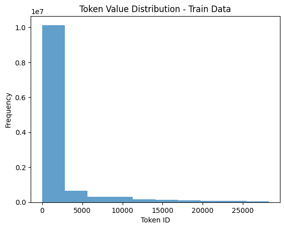

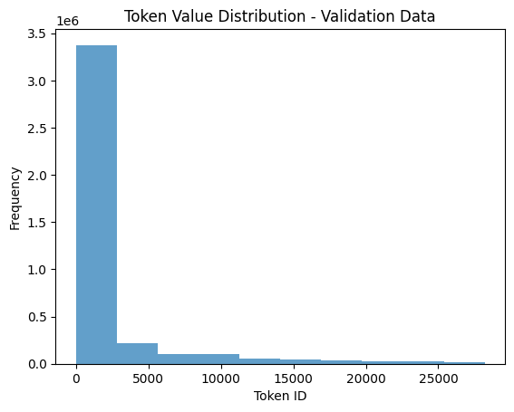

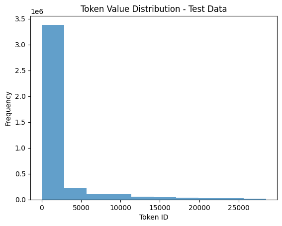

```python
# TO BE COMPLETED

all_token_ids_train = []

# Iterate over data_loader to collect token IDs
for sample in train_data_loader:
    input_ids = sample['input_ids']
    all_token_ids_train.extend(input_ids.flatten().tolist())

# Plot histogram
plt.hist(all_token_ids_train, bins=10, alpha=0.7)
plt.xlabel('Token ID')
plt.ylabel('Frequency')
plt.title('Token Value Distribution - Train Data')
plt.show()



all_token_ids_val = []

# Iterate over data_loader to collect token IDs
for sample in valid_data_loader:
    input_ids = sample['input_ids']
    all_token_ids_val.extend(input_ids.flatten().tolist())

# Plot histogram
plt.hist(all_token_ids_val, bins=10, alpha=0.7)
plt.xlabel('Token ID')
plt.ylabel('Frequency')
plt.title('Token Value Distribution - Validation Data')
plt.show()



all_token_ids_test = []

# Iterate over data_loader to collect token IDs
for sample in test_data_loader:
    input_ids = sample['input_ids']
    all_token_ids_test.extend(input_ids.flatten().tolist())

# Plot histogram
plt.hist(all_token_ids_test, bins=10, alpha=0.7)
plt.xlabel('Token ID')
plt.ylabel('Frequency')
plt.title('Token Value Distribution - Test Data')
plt.show()
```

```python
from collections import Counter

# Count occurrences of each token ID in the training data
token_id_counts = Counter(all_token_ids)

# Find top 5 occurring tokens
top_5_tokens = token_id_counts.most_common(5)

print("Top 5 Occurring Tokens in the Training Dataset:")
for token_id, count in top_5_tokens:
    print(f"Token ID: {token_id},  Count: {count}, Word: {tokenizer.decode(token_id)}")


# Count occurrences of each token ID in the training data
token_id_counts = Counter(all_token_ids_val)

# Find top 5 occurring tokens
top_5_tokens = token_id_counts.most_common(5)

print("Top 5 Occurring Tokens in the Validation Dataset:")
for token_id, count in top_5_tokens:
    print(f"Token ID: {token_id},  Count: {count}, Word: {tokenizer.decode(token_id)}")


# Count occurrences of each token ID in the training data
token_id_counts = Counter(all_token_ids_test)

# Find top 5 occurring tokens
top_5_tokens = token_id_counts.most_common(5)

print("Top 5 Occurring Tokens in the Test Dataset:")
for token_id, count in top_5_tokens:
    print(f"Token ID: {token_id},  Count: {count}, Word: {tokenizer.decode(token_id)}")
```

```
Top 5 Occurring Tokens in the Training Dataset:
Token ID: 0,  Count: 4293191, Word: [ P A D ]
Token ID: 119,  Count: 317646, Word: .
Token ID: 1103,  Count: 275924, Word: t h e
Token ID: 117,  Count: 259234, Word: ,
Token ID: 170,  Count: 153504, Word: a
Top 5 Occurring Tokens in the Validation Dataset:
Token ID: 0,  Count: 1421590, Word: [ P A D ]
Token ID: 119,  Count: 106808, Word: .
Token ID: 1103,  Count: 92427, Word: t h e
Token ID: 117,  Count: 87044, Word: ,
Token ID: 170,  Count: 51702, Word: a
Top 5 Occurring Tokens in the Test Dataset:
Token ID: 0,  Count: 1427481, Word: [ P A D ]
Token ID: 119,  Count: 106424, Word: .
Token ID: 1103,  Count: 92436, Word: t h e
Token ID: 117,  Count: 86945, Word: ,
Token ID: 170,  Count: 51093, Word: a
```

```python
'''
PROVIDE YOUR ANSWER BELOW
-------------------------------------------------------------

The top 5 occurring tokens in the training dataset, validation dataset, and
test dataset are as follows:

Training Dataset:

Token ID: 0, Count: 4293191, Word: [PAD]
Token ID: 119, Count: 317646, Word: .
Token ID: 1103, Count: 275924, Word: the
Token ID: 117, Count: 259234, Word: ,
Token ID: 170, Count: 153504, Word: a
Validation Dataset:

Token ID: 0, Count: 1421590, Word: [PAD]
Token ID: 119, Count: 106808, Word: .
Token ID: 1103, Count: 92427, Word: the
Token ID: 117, Count: 87044, Word: ,
Token ID: 170, Count: 51702, Word: a
Test Dataset:

Token ID: 0, Count: 1427481, Word: [PAD]
Token ID: 119, Count: 106424, Word: .
Token ID: 1103, Count: 92436, Word: the
Token ID: 117, Count: 86945, Word: ,
Token ID: 170, Count: 51093, Word: a
These tokens represent common symbols and words found in the dataset.


Token ID 0 ([PAD]): This token represents padding and is used to
standardize the length of sequences in the dataset.

Token ID 119 (.): This token represents a period,
indicating the end of a sentence.

Token ID 1103 (the): This token represents the word "the", which is one
of the most common words in the English language.

Token ID 117 (,): This token represents a comma, used for
punctuation within sentences.

Token ID 170 (a): This token represents "a", another common word in English.





'''
```

### Part (v) [1pt EXPLORATORY]

Select a single sample from your training DataLoader and feed it through the **bert_model** to obtain the hidden_states and pooled_output. Briefly describe what each tensor dimension represents and what affects the size of each dimension.

```python
# TO BE COMPLETED

# Get a single sample from the training DataLoader
for sample in train_data_loader:
    input_ids = sample['input_ids']
    attention_mask = sample['attention_mask']
    targets = sample['targets']
    break

# Feed the input IDs and attention mask through the BERT model
with torch.no_grad():
    outputs = bert_model(input_ids=input_ids, attention_mask=attention_mask)


hidden_states = outputs[0]
pooled_output = outputs[1]

hidden_size = bert_model.config.hidden_size

print("------------------------------------------------------------------")
print(hidden_size)
print(hidden_states.shape)
print(pooled_output.shape)
```

```
------------------------------------------------------------------
768
torch.Size([16, 400, 768])
torch.Size([16, 768])
```

```python
'''
PROVIDE YOUR ANSWER BELOW
--------------------------------------------------------------------------

In the above code, a single sample from the training DataLoader is
obtained, which consists of input IDs, attention masks, and targets.
This single sample is then fed through the BERT model to obtain
hidden_states and pooled_output.

hidden_states: This tensor represents the hidden states of each token in the
input sequence. It has a shape of [batch_size, sequence_length, hidden_size].

The batch_size dimension corresponds to the number of samples processed
in a single forward pass.

The sequence_length dimension represents the length of each input
sequence (in this case, 400 tokens).

The hidden_size dimension corresponds to the size of the hidden state
vectors, which is determined by the BERT model configuration (768 in this case).

The size of each dimension is affected by the batch size, sequence
length, and hidden size specified in the BERT model configuration.

pooled_output: This tensor represents the pooled output of the BERT model.
It provides a fixed-size representation of the entire input sequence,
It has a shape of [batch_size, hidden_size].


The size of each dimension is influenced by the batch size,
sequence length, and hidden size specified in the BERT model configuration.



'''
```

## Part 2. Model Architecture [2 pt]

### Part (i) [1pt MODEL]

Prepare a review classifier model that builds on the pooled output from the Bert model to identify positive and negative reviews.

```python
class SentimentClassifierPooled(nn.Module):
    def __init__(self, n_classes, p=0.3):
        super(SentimentClassifierPooled, self).__init__()
        self.bert = BertModel.from_pretrained(PRE_TRAINED_MODEL_NAME)
        for param in self.bert.parameters():  # Freeze BERT parameters
            param.requires_grad = False
        self.dropout = nn.Dropout(p)
        self.fc = nn.Linear(self.bert.config.hidden_size, n_classes)

    def forward(self, input_ids, attention_mask):
        pooled_output = self.bert(input_ids=input_ids, attention_mask=attention_mask)[1]
        pooled_output = self.dropout(pooled_output)
        output = self.fc(pooled_output)
        return output
```

### Part (ii) [1pt MODEL]

Construct the architecture for a review classifier model that uses the last hidden output from the Bert model to identify positive and negative reviews.

```python
class SentimentClassifierLast(nn.Module):
    def __init__(self, n_classes, p = 0.3):
        super(SentimentClassifierLast, self).__init__()
        self.bert = BertModel.from_pretrained(PRE_TRAINED_MODEL_NAME)
        for param in self.bert.parameters():
            param.requires_grad = False  # Freeze BERT parameters
        self.fc = nn.Sequential(
            nn.Linear(self.bert.config.hidden_size, 256),
            nn.LeakyReLU(0.2, inplace=True),
            nn.Dropout(p),
            nn.Linear(256, n_classes)
        )

    def forward(self, input_ids, attention_mask):
        outputs = self.bert(input_ids=input_ids, attention_mask=attention_mask)
        last_hidden_state = outputs.last_hidden_state
        pooled_output = last_hidden_state[:, 0, :]
        output = self.fc(pooled_output)
        return output
```

```python
#Quick Check

num_classes = 2  # Positive and negative classes
classifier_model = SentimentClassifierPooled(num_classes)
classifier_model_last = SentimentClassifierLast(num_classes)

# Sample text for classification
text = "This is a positive review. :)"

# Tokenize the text and convert it into PyTorch tensors
inputs = tokenizer(text, return_tensors='pt')

# Forward pass through the models
out1 = classifier_model(inputs.input_ids, inputs.attention_mask)
out2 = classifier_model_last(inputs.input_ids, inputs.attention_mask)

# Output the logits and probabilities for the first model
print("Output from Pooled Model:", out1)

# Output the logits and probabilities for the second model
print("Output from Last Model:", out2)
```

```
Output from Pooled Model: tensor([[-0.2873,  0.8378]], grad_fn=<AddmmBackward0>)
Output from Last Model: tensor([[0.1501, 0.1459]], grad_fn=<AddmmBackward0>)
```

## Part 3. Training [3 pt]

### Part (i) [1pt MODEL]

Complete the `get_accuracy` function, which will compute the accuracy (rate) of your model across a dataset (e.g. validation set).

```python
def get_accuracy(model, data_loader, device):
    """
    Compute the accuracy of the model across a dataset.

    Args:
        model: The model to evaluate.
        data_loader: DataLoader object containing the dataset.
        device: Device to use for computation (e.g., 'cuda' for GPU or 'cpu' for CPU).

    Returns:
        accuracy: The accuracy of the model on the dataset.
    """
    model.eval()
    correct, total = 0, 0

    with torch.no_grad():
        for data in data_loader:
            input_ids = data['input_ids'].to(device)
            attention_mask = data['attention_mask'].to(device)
            labels = data['targets'].to(device)

            outputs = model(input_ids, attention_mask)  # Forward pass
            _, predicted = torch.max(outputs, 1)  # Get the predicted labels
            correct += (predicted == labels).sum().item()  # Count correct predictions
            total += labels.size(0)  # Count total samples

    accuracy = correct / total if total > 0 else 0  # Compute accuracy
    return accuracy
```

```python
#checking if model and get_accuracy function working fine.

device = torch.device('cuda' if torch.cuda.is_available() else 'cpu')
model = SentimentClassifierPooled(2).to(device)

# Calculate accuracy on training and
train_accuracy = get_accuracy(model, train_data_loader, device)

print(f'Training Accuracy - Check: {train_accuracy:.2%}')
```

```
Training Accuracy - Check: 50.03%
```

### Part (ii) [1pt MODEL]

Write a function **train_model** to train your model. Plot the training curve of your final model. Your training curve should have the training/validation loss and accuracy plotted periodically.

```python
def train_model(model, train_loader, valid_loader, num_epochs=5, learning_rate=1e-5, device='cuda'):
    criterion = nn.CrossEntropyLoss()
    optimizer = torch.optim.Adam(model.parameters(), lr=learning_rate)
    model.to(device)  # Move model to GPU
    losses, train_acc, valid_acc = [], [], []

    for epoch in range(num_epochs):
        model.train()

        for data in train_loader:
            inputs = data['input_ids'].to(device)
            attention_mask = data['attention_mask'].to(device)
            labels = data['targets'].to(device)

            optimizer.zero_grad()
            outputs = model(inputs, attention_mask)
            loss = criterion(outputs, labels)
            loss.backward()
            optimizer.step()

        losses.append(float(loss))
        train_acc.append(get_accuracy(model, train_loader, device))  # Calculate training accuracy
        valid_acc.append(get_accuracy(model, valid_loader, device))  # Calculate validation accuracy

        print("Epoch %d; Loss %f; Train Acc %f; Val Acc %f" % (
            epoch+1, loss, train_acc[-1], valid_acc[-1]))

    # Plotting
    plt.title("Training Curve")
    plt.plot(losses, label="Train")
    plt.xlabel("Epoch")
    plt.ylabel("Loss")
    plt.show()

    plt.title("Accuracy Curve")
    plt.plot(range(1, num_epochs+1), train_acc, label="Train")
    plt.plot(range(1, num_epochs+1), valid_acc, label="Validation")
    plt.xlabel("Epoch")
    plt.ylabel("Accuracy")
    plt.legend(loc='best')
    plt.show()
```

### Part (iii) [1pt MODEL]

Choose at least 4 hyperparameters to tune. Explain how you tuned the hyperparameters. You don't need to include your training curve for every model you trained. Instead, explain what hyperparemters you tuned, what the best validation accuracy was, and the reasoning behind the hyperparameter decisions you made.

For this assignment, you should tune more than just your learning rate and epoch. Choose at least 2 hyperparameters that are unrelated to the optimizer.

```
Epoch 1; Loss 0.656318; Train Acc 0.618300; Val Acc 0.621100
```

```
Epoch 2; Loss 0.672717; Train Acc 0.634900; Val Acc 0.634800
```

```
Epoch 3; Loss 0.724667; Train Acc 0.645067; Val Acc 0.643700
```

```
Epoch 4; Loss 0.581594; Train Acc 0.653567; Val Acc 0.653200
```

```
Epoch 5; Loss 0.675712; Train Acc 0.659700; Val Acc 0.660600
```

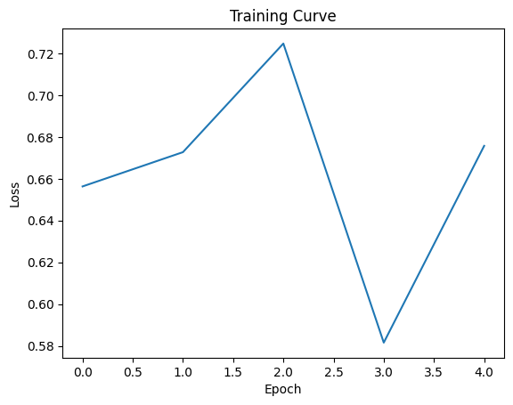

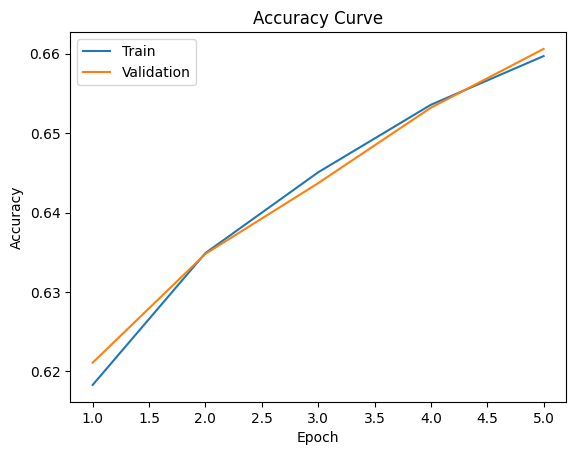

```
Epoch 1; Loss 0.587245; Train Acc 0.738067; Val Acc 0.741300
```

```
Epoch 2; Loss 0.446920; Train Acc 0.761000; Val Acc 0.768400
```

```
Epoch 3; Loss 0.427042; Train Acc 0.777033; Val Acc 0.783100
```

```
Epoch 4; Loss 0.307601; Train Acc 0.786100; Val Acc 0.789400
```

```
Epoch 5; Loss 0.386433; Train Acc 0.789667; Val Acc 0.792100
```

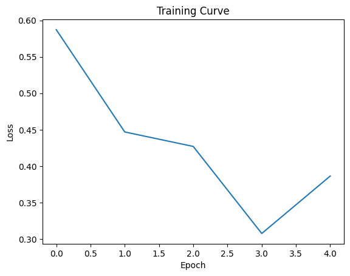

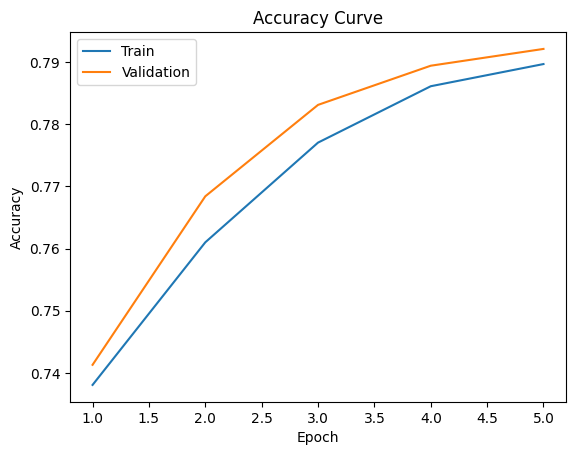

```python
device = torch.device("cuda" if torch.cuda.is_available() else "cpu")

model_pooled_1 = SentimentClassifierPooled(2)
train_model(model_pooled_1, train_data_loader, valid_data_loader, num_epochs=5, learning_rate=1e-5, device=device)


model_last_1 = SentimentClassifierLast(2)
train_model(model_last_1, train_data_loader, valid_data_loader, num_epochs=5, learning_rate=1e-5, device=device)
```

```
Epoch 1; Loss 0.617992; Train Acc 0.622167; Val Acc 0.618000
```

```
Epoch 2; Loss 0.669952; Train Acc 0.631600; Val Acc 0.628600
```

```
Epoch 3; Loss 0.717193; Train Acc 0.642867; Val Acc 0.641600
```

```
Epoch 4; Loss 0.683567; Train Acc 0.654000; Val Acc 0.652300
```

```
Epoch 5; Loss 0.630796; Train Acc 0.661967; Val Acc 0.658700
```

```
Epoch 6; Loss 0.661884; Train Acc 0.669567; Val Acc 0.667800
```

```
Epoch 7; Loss 0.792600; Train Acc 0.674800; Val Acc 0.674900
```

```
Epoch 8; Loss 0.723650; Train Acc 0.679400; Val Acc 0.680900
```

```
Epoch 9; Loss 0.629884; Train Acc 0.684067; Val Acc 0.684900
```

```
Epoch 10; Loss 0.667266; Train Acc 0.687467; Val Acc 0.688500
```

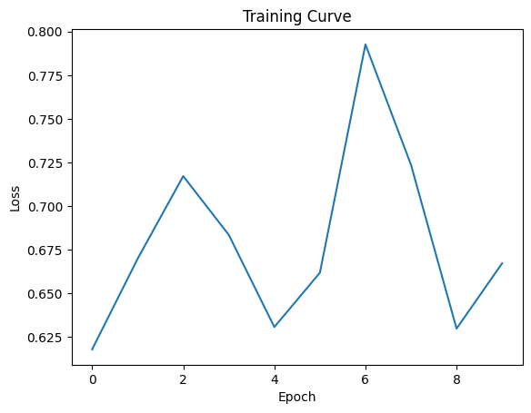

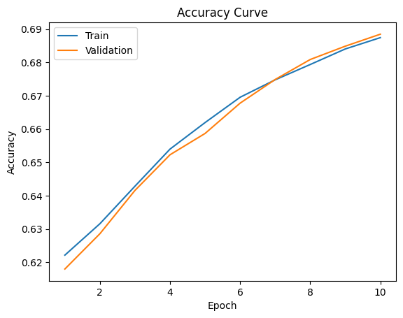

```
Epoch 1; Loss 0.586082; Train Acc 0.733967; Val Acc 0.738900
```

```
Epoch 2; Loss 0.529697; Train Acc 0.759833; Val Acc 0.764900
```

```
Epoch 3; Loss 0.579985; Train Acc 0.776400; Val Acc 0.781000
```

```
Epoch 4; Loss 0.410751; Train Acc 0.783867; Val Acc 0.784900
```

```
Epoch 5; Loss 0.413106; Train Acc 0.789833; Val Acc 0.790500
```

```
Epoch 6; Loss 0.465574; Train Acc 0.793700; Val Acc 0.794900
```

```
Epoch 7; Loss 0.456748; Train Acc 0.796733; Val Acc 0.799300
```

```
Epoch 8; Loss 0.418538; Train Acc 0.798800; Val Acc 0.801100
```

```
Epoch 9; Loss 0.390113; Train Acc 0.801767; Val Acc 0.802100
```

```
Epoch 10; Loss 0.361412; Train Acc 0.803600; Val Acc 0.804100
```

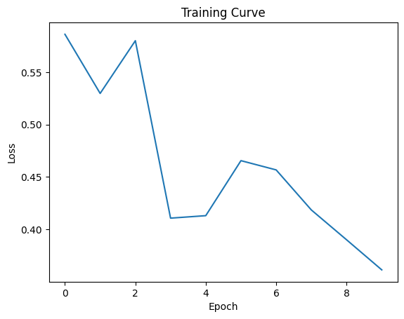

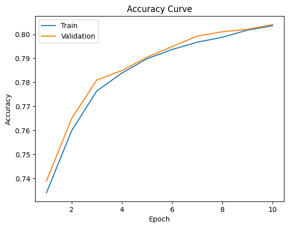

```python
device = torch.device("cuda" if torch.cuda.is_available() else "cpu")

model_pooled_2 = SentimentClassifierPooled(2)
train_model(model_pooled_2, train_data_loader, valid_data_loader, num_epochs=10, learning_rate=1e-5, device=device)


model_last_2 = SentimentClassifierLast(2)
train_model(model_last_2, train_data_loader, valid_data_loader, num_epochs=10, learning_rate=1e-5, device=device)
```

```
Epoch 1; Loss 0.637634; Train Acc 0.674033; Val Acc 0.678400
```

```
Epoch 2; Loss 0.606588; Train Acc 0.694000; Val Acc 0.694700
```

```
Epoch 3; Loss 0.589014; Train Acc 0.703067; Val Acc 0.705300
```

```
Epoch 4; Loss 0.635214; Train Acc 0.714200; Val Acc 0.715400
```

```
Epoch 5; Loss 0.679102; Train Acc 0.722133; Val Acc 0.721100
```

```
Epoch 6; Loss 0.637130; Train Acc 0.720833; Val Acc 0.720100
```

```
Epoch 7; Loss 0.550348; Train Acc 0.729600; Val Acc 0.730100
```

```
Epoch 8; Loss 0.559850; Train Acc 0.730833; Val Acc 0.732500
```

```
Epoch 9; Loss 0.590932; Train Acc 0.735267; Val Acc 0.738800
```

```
Epoch 10; Loss 0.719052; Train Acc 0.735067; Val Acc 0.736800
```

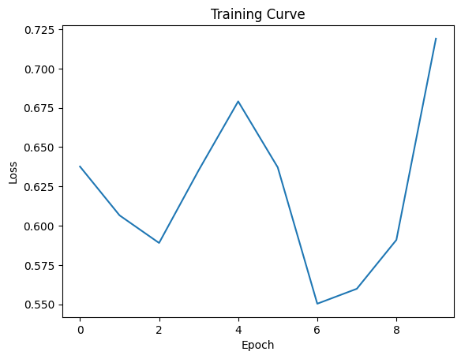

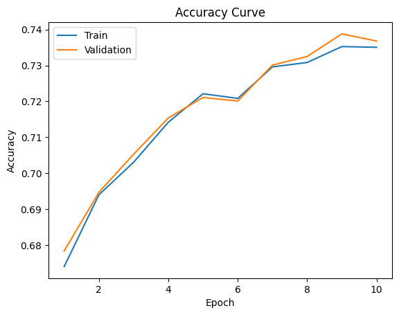

[output not shown]

[output not shown]

[output not shown]

[output not shown]

[output not shown]

[output not shown]

[output not shown]

[output not shown]

[output not shown]

[output not shown]

[figure not shown]

[figure not shown]

```python
device = torch.device("cuda" if torch.cuda.is_available() else "cpu")

model_pooled_3 = SentimentClassifierPooled(2)
train_model(model_pooled_3, train_data_loader, valid_data_loader, num_epochs=10, learning_rate=1e-4, device=device)
```

```
Epoch 1; Loss 0.399206; Train Acc 0.796500; Val Acc 0.800600
```

```
Epoch 2; Loss 0.436970; Train Acc 0.808000; Val Acc 0.810300
```

```
Epoch 3; Loss 0.357305; Train Acc 0.811200; Val Acc 0.810300
```

```
Epoch 4; Loss 0.399172; Train Acc 0.817733; Val Acc 0.815400
```

```
Epoch 5; Loss 0.377421; Train Acc 0.820167; Val Acc 0.818200
```

```
Epoch 6; Loss 0.417512; Train Acc 0.818900; Val Acc 0.816600
```

```
Epoch 7; Loss 0.428139; Train Acc 0.823633; Val Acc 0.820000
```

```
Epoch 8; Loss 0.307179; Train Acc 0.826300; Val Acc 0.821400
```

```
Epoch 9; Loss 0.322424; Train Acc 0.827033; Val Acc 0.823000
```

```
Epoch 10; Loss 0.388755; Train Acc 0.828200; Val Acc 0.825200
```

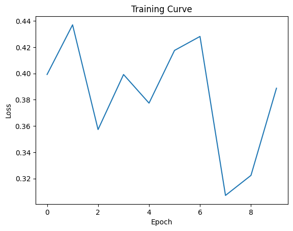

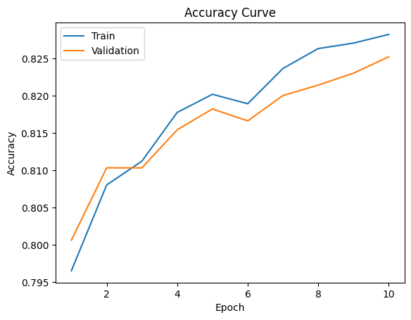

```python
device = torch.device("cuda" if torch.cuda.is_available() else "cpu")

model_last_3 = SentimentClassifierLast(2)
train_model(model_last_3, train_data_loader, valid_data_loader, num_epochs=10, learning_rate=1e-4, device=device)
torch.save(model_last_3,'model_3.pth')
```